# Exploratory Analysis

We are studying how educational data highlights social injustices. Variables such as school amenities, school funding, graduation rate, dropout rate, and more could demonstrate what districts are receiving disproportionately high or low support. We will investigate how primary and secondary education data relates to post-secondary (post-graduation) education data. If able, we are also interested in analyzing how access to environmental education and outdoor spaces impacts students post-graduation (such impacts could include belief in climate change). Social and environmental justice are connected because the impacts of climate change disproportionately affect low-income communities (and due to systematic injustices people of color disproportionately make up low income communities). Low-income communities have less resilience to storms and environmental crises caused by climate change, so it is important to preemptively investigate what communities are most affected by social and environmental injustices. We believe that education data may highlight many of these injustices and we are interested in uncovering some these problems. It is critical that we continue uncovering social and environmental injustices to protect the health and well-being of all communities.

# Summary Information

For our summary information, we were interested in highlighting the poverty rates and access to education that exists in specific communities. We were also interested in learning how an access to education may affect the perspectives of different communities on environmental issues such as climate change. After calculating the number of different school districts, counties, and neighborhoods in our data, we were able to dive into the percentage of people who supported environmental topics such as capping CO2 emissions and teaching children about climate change on a national, state, and county level using data from the Yale Climate Opinion Project. Our data represents 3142 different counties across the country. About 61.8% of the national populations supports capping CO2 emissions while 73.5% of the population supports teaching about the concept of climate change in schools. Furthermore, we calculated the average income-to-poverty ratio of the neighborhoods depicted in our dataset from the NCES, which is depicted as a range from 0-999, the lower numbers indicating more impoverished locations. We found that the minimum IPR was 35 while the highest was 986. We were also able to calculate the average IPR across the U.S. which falls at 293.8268341 while the poverty line currently stands at an IPR of about 100.

# Summary Table

| State | Support_Controlling_CO2_Emissions | Support_Teaching_about_Global_Warming | Average_CWIFT |
| --- | --- | --- | --- |
| Arizona | 65.537 | 76.645 | 0.0341333 |
| California | 72.055 | 81.489 | 0.0378793 |
| Georgia | 64.544 | 77.021 | 0.0487673 |
| Illinois | 71.328 | 78.602 | 0.0422843 |
| New York | 74.879 | 83.311 | 0.0373710 |
| Oregon | 68.101 | 77.667 | 0.0408611 |
| South Dakota | 62.814 | 74.116 | 0.0408333 |
| Washington | 72.032 | 79.256 | 0.0372051 |

We decided to include this table on Climate Education as compared to the Comparable Wage Index for Teachers because it displays important information on the amount of approval by state for climate change education and supporting the regulation of CO2 and gas emissions, which may be correlated to differences in the regional variations of salaries for teachers in different states. Furthermore, this table reflects how people in different states may support or oppose certain issues and how this relates to the rates of pay for teachers and differences in access to environmental education in a particular state.

# Map Chart

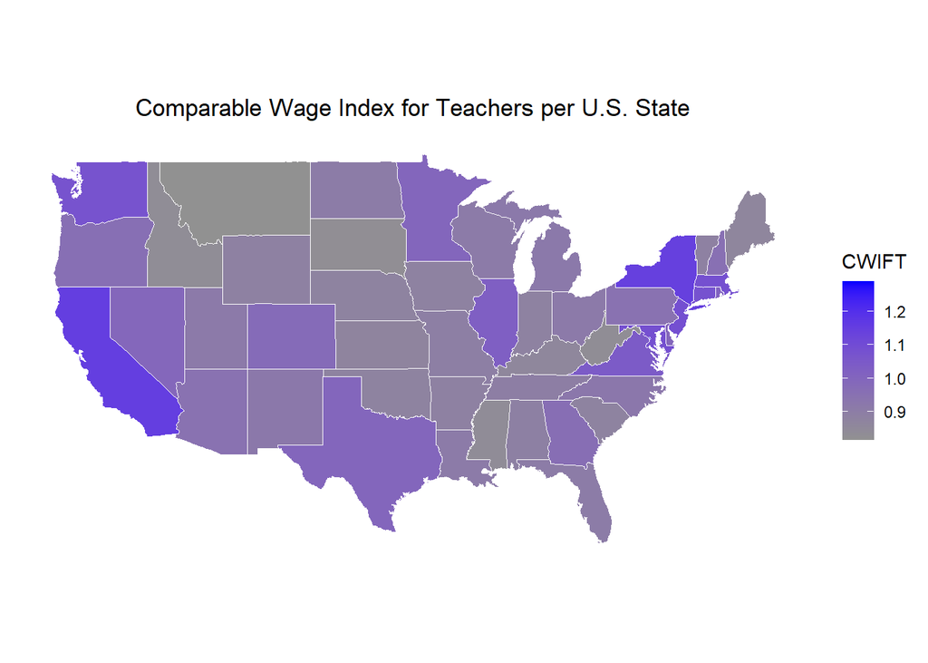

The **Comparable Wage Index for Teachers (CWIFT)** is a complex cost index estimate generated by the National Center for Education Statistics (NCES) to allow researchers to adjust education finance data for comparison across geographic regions, down to the per-district level. The CWIFT value for each school district is an estimate of the cost index for that region, and is reflective of the cost for the same amount of value from education spending. The NCES provides CWIFT estimates at the school district level, but this chart shows the CWIFT estimate per state to help demonstrate the concept.

# Poverty and Technology Chart

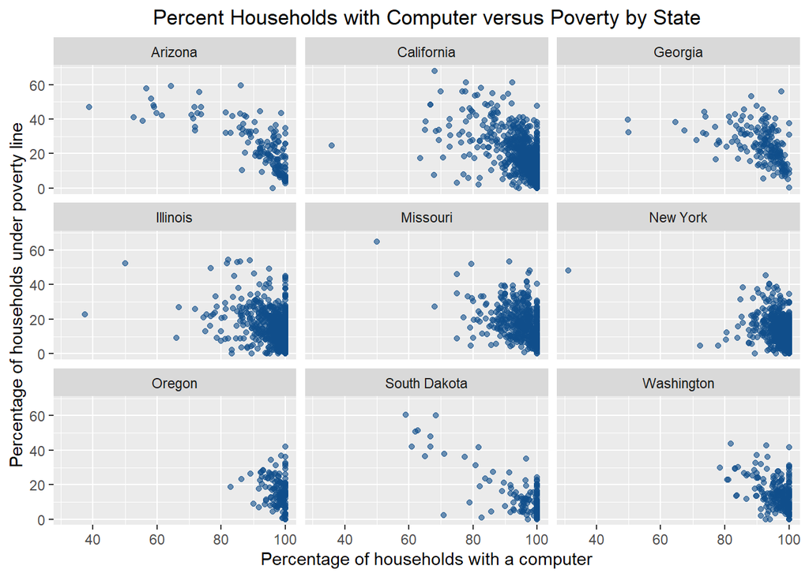

The NCES data was used in this chart to compare the percentage of households with a computer to the percentage of households under the poverty line in each district. We analyzed this data by state to look more closely at how this data changed based on location. This data shows a general trend in most cases of districts with a higher percentage of households below the poverty level having a lower percentage of households with a computer. In further analysis, it would be interesting to see how this data correlated with education success such as high school or college graduation rates. The purpose of including the information as seen in the chart is to determine a baseline understanding of if these two variables correlate, and then we will be able to incorporate a deeper analysis based off this. We included these specific 9 states to show a variety of west coast, east coast, and central states. After looking extensively through all the states by charting each of them with this data, we chose the ones with stronger visible correlation to indicate that there may be a relationship between these variables,but in future analysis we would like to include more states to ensure our data is unbiased.

# United States Climate Opinion Chart

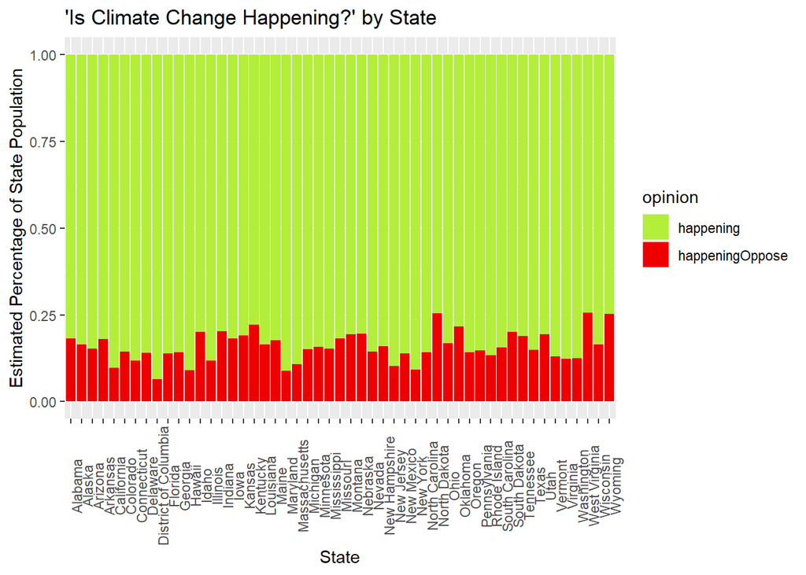

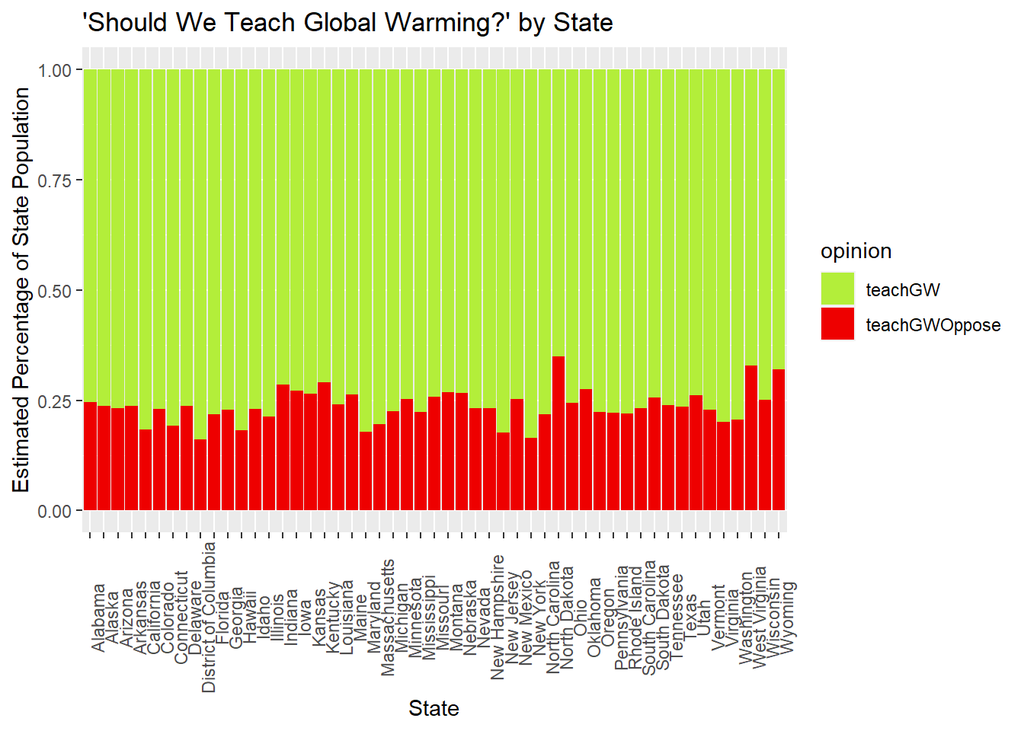